# Lab 4

Melissa Widas

2024-04-24

Lab 4 Assignment: Due May 7 at 11:59pm

1. Select another classification algorithm.

**I am going to choose Random Forest**

2. Conduct an initial out-of-the-box model fit on the training data and prediction on the test data. Assess the performance of this initial model.

```r
library(tidytext)
library(tidyverse)
library(tidymodels)
library(textrecipes)
library(randomForest) # naive-bayes
library(vip)


# load data
urlfile ="https://raw.githubusercontent.com/MaRo406/EDS-231-text-sentiment/main/data/climbing_reports_model_dat.csv"
incidents_df<-readr::read_csv(url(urlfile))

set.seed(1234)

# split data
incidents2class <- incidents_df %>%
  mutate(fatal = factor(if_else(
                        is.na(Deadly),
                        "non-fatal", "fatal")))


incidents_split <- initial_split(incidents2class, strata = fatal)

incidents_train <- training(incidents_split)
incidents_test <- testing(incidents_split)

# create recipe
incidents_rec <- recipe(fatal ~ Text, data = incidents_train)

# recipe pre-processing
recipe <- incidents_rec %>%
  step_tokenize(Text) %>%
  step_tokenfilter(Text, max_tokens = 1000) %>%
  step_tfidf(Text)

# models spec
rf_spec <- rand_forest() %>%
  set_mode("classification") %>%
  set_engine("ranger")

# make folds
incidents_folds <- vfold_cv(incidents_train)

# tidymodels workflow
incidents_wf <- workflow() %>%
  add_recipe(recipe) |>
  add_model(rf_spec)

# model fit
rf_rs <- fit_resamples(
  incidents_wf,
  incidents_folds,
  control = control_resamples(save_pred = T)
)

rf_rs_metrics <- collect_metrics(rf_rs)
rf_rs_predictions <- collect_predictions(rf_rs)

rf_rs_metrics
```

```
## # A tibble: 2 × 6
##   .metric  .estimator  mean     n std_err .config
##   <chr>    <chr>      <dbl> <int>   <dbl> <chr>
## 1 accuracy binary     0.866    10 0.0120  Preprocessor1_Model1
## 2 roc_auc  binary     0.956    10 0.00487 Preprocessor1_Model1
```

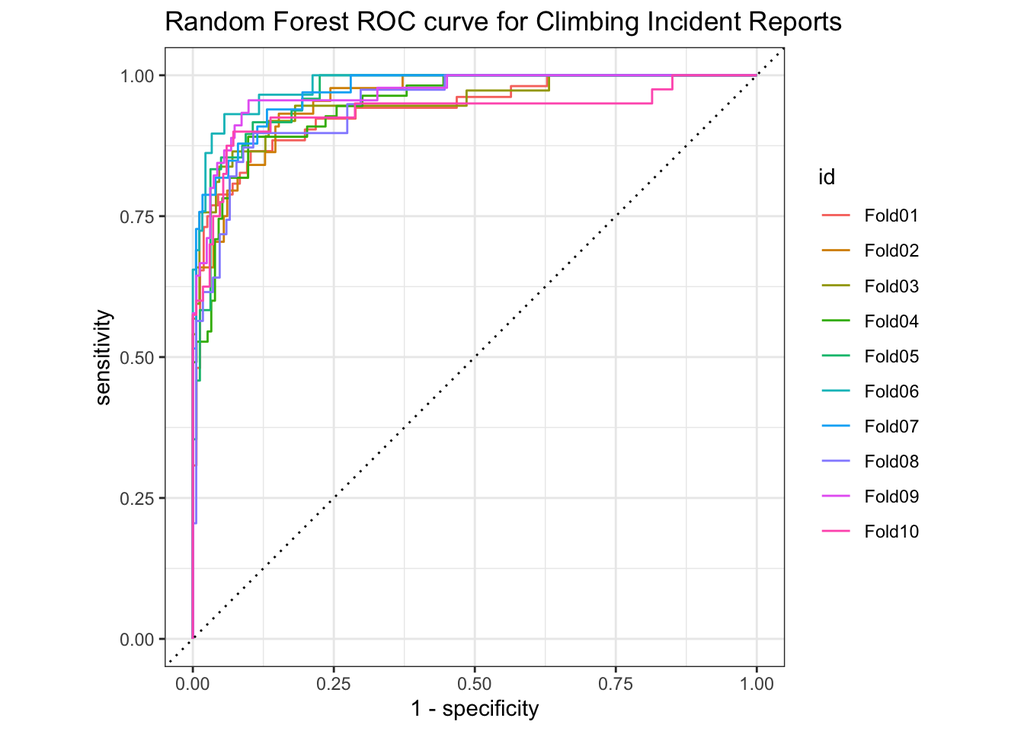

```r
# rf_rs_predictions

box_roc <- rf_rs_predictions |>
  group_by(id) |>
  roc_curve(truth = fatal, .pred_fatal) |>
  autoplot() +
  labs("Resamples", title = "Random Forest ROC curve for Climbing Incident Reports")

box_roc
```

**The initial performance of this model was had an accuracy of 0.866 and roc-auc of 0.956.**

3. Select the relevant hyperparameters for your algorithm and tune your model.

**The hyperparameters I will be tuning for this model will be `mtry()` and the number of `trees()`.**

4. Conduct a model fit using your newly tuned model specification. How does it compare to your out-of-the-box model?

```r
rf_spec_tune <- rand_forest(mtry = tune(),
                  trees = tune()) |>
  set_engine("ranger", importance = "impurity") |>
  set_mode("classification")

# make folds
incidents_folds <- vfold_cv(incidents_train)

# tidymodels workflow
incidents_wf_tune <- workflow() %>%
  add_recipe(recipe) |>
  add_model(rf_spec_tune)

#use cross validation to tune mtry and trees parameters
# took some time to load so write to .rda file for ease of use
# rf_cv_tune = incidents_wf_tune %>%
#   tune_grid(resamples = incidents_folds, grid = 10)

#write_rds(rf_cv_tune, "rf_tune.rda")
rf_cv_tune <- read_rds("rf_tune.rda")

rf_incidents_tune_final <- finalize_workflow(incidents_wf_tune,
                             select_best(rf_cv_tune, metric = "roc_auc"))

# model fit
rf_tune_rs <- fit_resamples(
  rf_incidents_tune_final,
  incidents_folds,
  control = control_resamples(save_pred = T)
)

rf_tune_rs_metrics <- collect_metrics(rf_tune_rs)
rf_tune_rs_predictions <- collect_predictions(rf_tune_rs)

rf_tune_rs_metrics
```

```
## # A tibble: 2 × 6
##   .metric  .estimator  mean     n std_err .config
##   <chr>    <chr>      <dbl> <int>   <dbl> <chr>
## 1 accuracy binary     0.826    10 0.0109  Preprocessor1_Model1
## 2 roc_auc  binary     0.956    10 0.00375 Preprocessor1_Model1
```

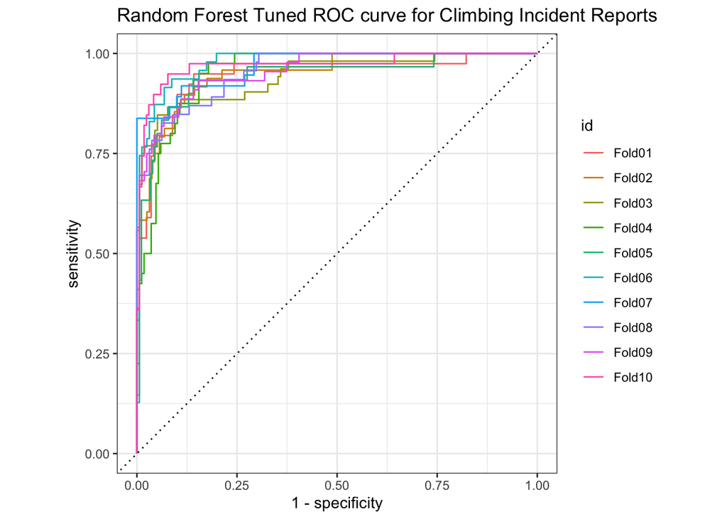

```r
# rf_tune_rs_predictions

tune_roc <- rf_tune_rs_predictions |>
  group_by(id) |>
  roc_curve(truth = fatal, .pred_fatal) |>
  autoplot() +
  labs("Resamples", title = "Random Forest Tuned ROC curve for Climbing Incident Reports")

tune_roc
```

**My tuned model is very similar to my out of the box model with a slightly lower accuracy. My tuned model had an accuracy of 0.826 and had a roc_auc of 0.956. The accuracy and the ROC-AUC remained consistent.**

5. 1. Use variable importance to determine the terms most highly associated with non-fatal reports? What about terms associated with fatal reports? OR
   2. If you aren’t able to get at variable importance with your selected algorithm, instead tell me how you might in theory be able to do it. Or how you might determine the important distinguishing words in some other way.

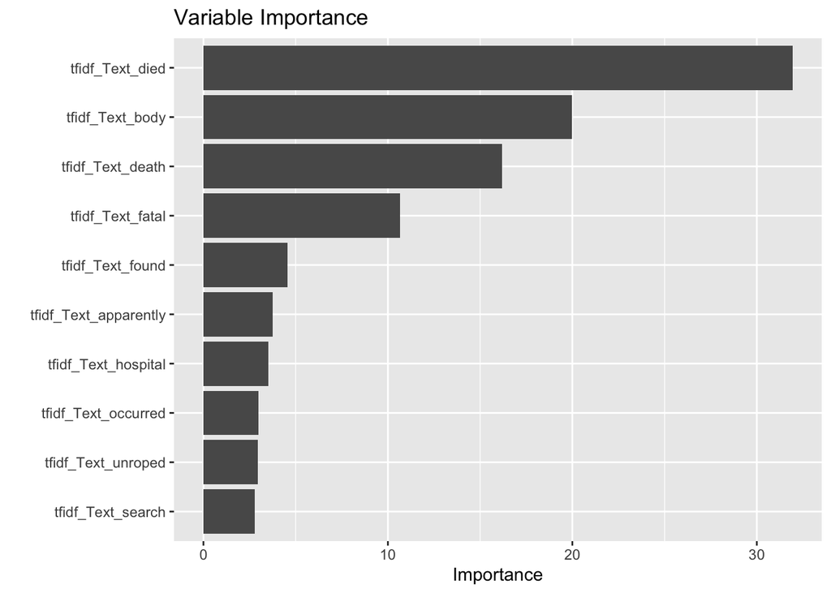

```r
#fit the random forest model to the training set and extract variable importance
fatal_vip <- fit(rf_incidents_tune_final, incidents_train) |>
  extract_fit_parsnip() |>
  vip() +
  labs(title = "Variable Importance")

fatal_vip
```

**Variable importance for a ranger model is showing the variables that seprate the prediction classes the most, but it does not necessarily separate it into predicting fatal vs non-fatal in terms of importance. Therefore the top 10 words shown are the 10 most important words for separating the prediction classes not necessarily for the specific classes.**

6. Predict fatality of the reports in the test set. Compare this prediction performance to that of the Naive Bayes and Lasso models. Why do you think your model performed as it did, relative to the other two?

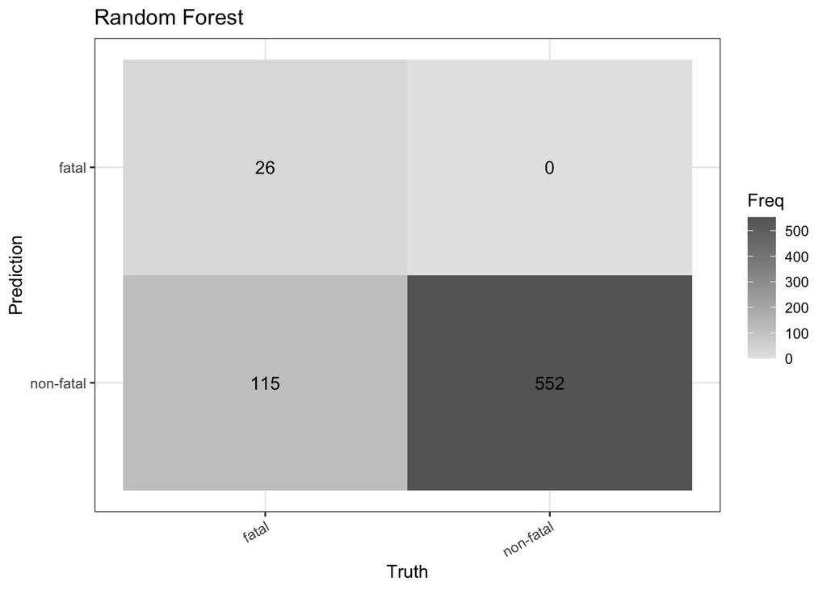

```r
train_fit_rf <- fit(rf_incidents_tune_final, incidents_train) #fit the random forest model to the training set

test_predict_rf = predict(train_fit_rf, incidents_test) %>% #get prediction probabilities for test
  bind_cols(incidents_test) %>%  #bind to testing column
  mutate(fatal = as.factor(fatal))

test_predict_rf %>%
  conf_mat(truth = fatal, estimate = .pred_class) %>% #create confusion matrix
  autoplot(type = "heatmap") + #plot confusion matrix with heatmap
  theme_bw() + #change theme
  theme(axis.text.x = element_text(angle = 30, hjust=1)) +
  #rotate axis labels
  labs(title = "Random Forest")
```

Naive-Boyes

```
  .metric  .estimator  mean     n std_err .config
  <chr>    <chr>      <dbl> <int>   <dbl> <chr>
1 accuracy binary     0.797    10 0.00944 Preprocessor1_Model1
2 roc_auc  binary     0.722    10 0.0123  Preprocessor1_Model1
```

Lasso

```
  .metric  .estimator .estimate .config
  <chr>    <chr>          <dbl> <chr>
1 accuracy binary         0.916 Preprocessor1_Model1
2 roc_auc  binary         0.951 Preprocessor1_Model1
```

Out-of-the-box Random Forest

```
 .metric  .estimator  mean     n std_err .config
  <chr>    <chr>      <dbl> <int>   <dbl> <chr>
1 accuracy binary     0.866    10 0.0120  Preprocessor1_Model1
2 roc_auc  binary     0.956    10 0.00487 Preprocessor1_Model1
```

Tuned Random Forest

```
  .metric  .estimator  mean     n std_err .config
  <chr>    <chr>      <dbl> <int>   <dbl> <chr>
1 accuracy binary     0.826    10 0.0109  Preprocessor1_Model1
2 roc_auc  binary     0.956    10 0.00375 Preprocessor1_Model1
```